## Load libraries

Firstly, let’s load the libraries that we will use.

They will need to be installed first if you don’t already have them.

```r
#install.packages("readxl")
library(readxl)
#install.packages("RNetCDF")
library(RNetCDF)
```

## Loading and checking the data

Let’s look at the data we are working with first:

```r
data <- read_excel("chlorophyll_a_depth_profile_variables.xlsx")
print(data, n=Inf)
```

```
## # A tibble: 10 × 9
##    eventID  parentEventID eventTime stationName decimalLatitude decimalLongitude
##    <chr>    <chr>         <chr>     <chr>                 <dbl>            <dbl>
##  1 fe94bd4… fe94e17a-dfb… 2019-04-… P1 (NLEG01)            76.0             31.2
##  2 fe94bfe… fe94e17a-dfb… 2019-04-… P1 (NLEG01)            76.0             31.2
##  3 fe94c0d… fe94e17a-dfb… 2019-04-… P1 (NLEG01)            76.0             31.2
##  4 fe94c2d… fe94e17a-dfb… 2019-04-… P1 (NLEG01)            76.0             31.2
##  5 fe94c3a… fe94e17a-dfb… 2019-04-… P1 (NLEG01)            76.0             31.2
##  6 fe94c46… fe94e17a-dfb… 2019-04-… P1 (NLEG01)            76.0             31.2
##  7 fe94c5b… fe94e17a-dfb… 2019-04-… P1 (NLEG01)            76.0             31.2
##  8 fe94c67… fe94e17a-dfb… 2019-04-… P1 (NLEG01)            76.0             31.2
##  9 fe94c7d… fe94e17a-dfb… 2019-04-… P1 (NLEG01)            76.0             31.2
## 10 fe94c88… fe94e17a-dfb… 2019-04-… P1 (NLEG01)            76.0             31.2
## # … with 3 more variables: bottomDepthInMeters <dbl>,
## #   sampleDepthInMeters <dbl>,
## #   mass_concentration_of_chlorophyll_a_in_sea_water <dbl>
```

We have a depth profile of Chlorophyll A data. Most of the column headers are taken from the spreadsheet templates generators that were used to log the metadata.

https://www.sios-svalbard.org/cgi-bin/darwinsheet/?setup=aen

Other columns headers, for the data, are taken from the CF standard names. This is a common vocabulary, where parameter names can be searched for online, with descriptions, so that everyone is clear what the data represent.

http://cfconventions.org/standard-names.html

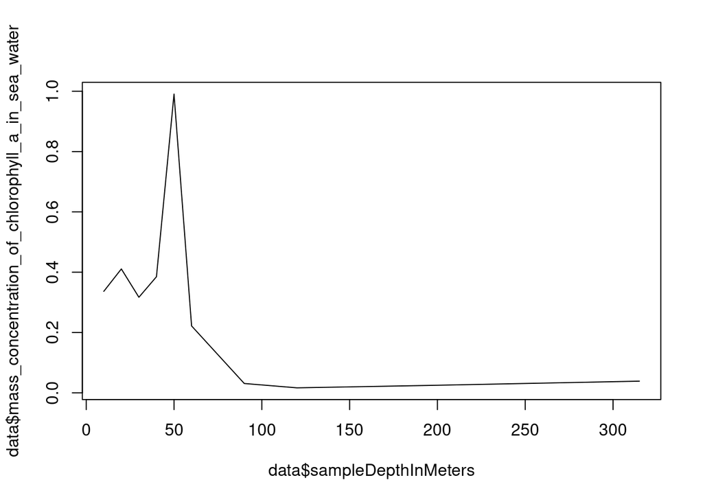

```r
plot(data$sampleDepthInMeters, data$mass_concentration_of_chlorophyll_a_in_sea_water, type ="l")
```

## Creating NetCDF file

First let’s initialise the dataset.

```r
nc <- create.nc("chlorophyll_a_depth_profile.nc")
```

### Defining dimensions

A NetCDF file has dimensions that define the shape of the data. In this case, our main dimension is the sample depth, and we have 10 depths. ‘depth’ is a commonly defined dimension name, so to be CF-compliant, we should use that. Note that at this point we are not assigning values for the depths.

```r
dim.def.nc(nc, "depth", nrow(data))
```

### Defining variables

A NetCDF has both coordinate variables and data variables. Dimensions define how many grid points there are, coordinate variables define what the actual values are.

Let’s now initialise our variables. We will assign our values later.

```r
var.def.nc(nc, "depth", "NC_INT", "depth")
var.def.nc(nc, "chlorophyll_a", "NC_DOUBLE", "depth")
```

### Event IDs

We can store our eventIDs for each sample in our NetCDF file too. Depending on the version of R and RNetCDF you are using, you might need to create a new dimension first that states the maximum number of characters that can exist in a string - 36 in this case.

The following two lines of code may not be necessary in newer version of R and RNetCDF. NetCDF itself supporting multiple character strings for variables is a relatively new thing.

```r
dim.def.nc(nc, "max_string_length", 36)
var.def.nc(nc,"eventid","NC_CHAR",c("max_string_length","depth"))
```

### Variable attributes

Now we need a variable attributes for our variables, so that our dataset is compliant with the CF conventions.

The standard_name should be selected from here: http://cfconventions.org/standard-names.html. Standard names are commonly accepted parameter names with descriptions. By selecting appropriate standard names for your variable, the data user will be clear exactly what the data represent.

The units should match what is provided for the standard name as listed above. You may need to convert your data.

The long_name is more descriptive and can be in your own words.

The coverage_content_type describes what type of data the variable contains

Some help on these variable attributes can be found here: https://commons.esipfed.org/acdd_1-3_references

The data variable should be assigned a fill value. This is a value that is used at grid points where no data exists. We usually choose an unrealistically large value that will obviously appear as a spike to the data user. The fill value is later specified as a variable attribute. Note that coordinate variables should not have fill values as they should not have missing values.

```r
att.put.nc(nc, "depth", "units", "NC_CHAR", "m")
att.put.nc(nc, "depth", "long_name", "NC_CHAR", "sample depth in meters")
att.put.nc(nc, "depth", "standard_name", "NC_CHAR", "depth")
att.put.nc(nc, "depth", "coverage_content_type", "NC_CHAR", "coordinate")

att.put.nc(nc, "chlorophyll_a", "standard_name", "NC_CHAR", "mass_concentration_of_chlorophyll_a_in_sea_water")
att.put.nc(nc, "chlorophyll_a", "long_name", "NC_CHAR", "Mass concentration of Chlorophyll A in sea water, after acid correction")
att.put.nc(nc, "chlorophyll_a", "coverage_content_type", "NC_CHAR", "physicalMeasurement")
att.put.nc(nc, "chlorophyll_a", "units", "NC_CHAR", "kg m-3")
att.put.nc(nc, "chlorophyll_a", "_FillValue", "NC_DOUBLE", -99999.9)

att.put.nc(nc, "eventid", "long_name", "NC_CHAR", "Univerisally unique ID for each sample. eventID taken from the Darwin Core standard (https://dwc.tdwg.org/list/#dwc_eventID). More information on each sample can be found by searching using the eventID in the Nansen Legacy metadata catalogue (https://sios-svalbard.org/aen/tools).")
att.put.nc(nc, "eventid", "coverage_content_type", "NC_CHAR", "referenceInformation")
```

Now it’s time to populate the variables with our data

```r
var.put.nc(nc, "depth", data$sampleDepthInMeters)
var.put.nc(nc, "chlorophyll_a", data$mass_concentration_of_chlorophyll_a_in_sea_water)
var.put.nc(nc, "eventid", data$eventID)
```

### Gloabl attributes

Global attributes describe the dataset as a whole. A list of what global attributes must be included can be found here:

https://adc.met.no/node/4

These are based on the ACDD conventions, that you can find here:

https://wiki.esipfed.org/Attribute_Convention_for_Data_Discovery_1-3

We refer to which conventions the file adheres to (including version) in the ‘conventions’ global attribute.

Additional global attributes can also be included, defined by the user. Make sure that the attribute names you select are understandable.

To save you from having to write them all out, I have written them in a separate file that you can load in as below.

```r
global_attributes <- read_excel("chlorophyll_a_depth_profile_global_attributes.xlsx")
```

Now we can iterate over each row and write each attribute in turn. We do this by using a special attribute name, NC_GLOBAL.

```r
for(i in 1:nrow(global_attributes)) {
    row <- global_attributes[i,]
    if (row$Format == "NC_DOUBLE") {
      att.put.nc(nc, "NC_GLOBAL", row$AttributeName, "NC_DOUBLE", as.double(row$Content))
    }
    else {
      att.put.nc(nc, "NC_GLOBAL", row$AttributeName, "NC_CHAR", row$Content)
    }
}
```

We should update some of the attributes to include the current timestamp.

```r
dtnow <- format(Sys.time(), tz = "UTC", "%FT%R:%SZ")
att.put.nc(nc, "NC_GLOBAL", "date_created", "NC_CHAR", dtnow)
att.put.nc(nc, "NC_GLOBAL", "history", "NC_CHAR", paste("File created using RNetCDF in R at",dtnow))
```

Finally, we close the file to ensure that it is written and that everything is complete.

```r
close.nc(nc)
```

We can then open it up and print it to check if everything looks okay!

```r
nc <- open.nc("chlorophyll_a_depth_profile.nc")
print.nc(nc)
```

```
## netcdf classic {
## dimensions:
##  depth = 10 ;
##  max_string_length = 36 ;
## variables:
##  NC_INT depth(depth) ;
##      NC_CHAR depth:units = "m" ;
##      NC_CHAR depth:long_name = "sample depth in meters" ;
##      NC_CHAR depth:standard_name = "depth" ;
##      NC_CHAR depth:coverage_content_type = "coordinate" ;
##  NC_DOUBLE chlorophyll_a(depth) ;
##      NC_CHAR chlorophyll_a:standard_name = "mass_concentration_of_chlorophyll_a_in_sea_water" ;
##      NC_CHAR chlorophyll_a:long_name = "Mass concentration of Chlorophyll A in sea water, after acid correction" ;
##      NC_CHAR chlorophyll_a:coverage_content_type = "physicalMeasurement" ;
##      NC_CHAR chlorophyll_a:units = "kg m-3" ;
##      NC_DOUBLE chlorophyll_a:_FillValue = -99999.9 ;
##  NC_CHAR eventid(max_string_length, depth) ;
##      NC_CHAR eventid:long_name = "Univerisally unique ID for each sample. eventID taken from the Darwin Core standard (https://dwc.tdwg.org/list/#dwc_eventID). More information on each sample can be found by searching using the eventID in the Nansen Legacy metadata catalogue (https://sios-svalbar…
##      NC_CHAR eventid:coverage_content_type = "referenceInformation" ;
##
## // global attributes:
##      NC_CHAR :title = "Chlorophyll A measurements from the P1 (NLEG01) station in the Northern Barents Sea" ;
##      NC_CHAR :naming_authority = "University Centre in Svalbard (UNIS)" ;
##      NC_CHAR :id = "c4a1108a-2683-425d-9ad1-f23fd79e5224" ;
##      NC_CHAR :summary = "ANALAGOUS TO AN ABSTRACT IN A PAPER" ;
##      NC_CHAR :keywords = "Oceans > Ocean Chemistry > Chlorophyll" ;
##      NC_CHAR :keywords_vocabulary = "GCMD" ;
##      NC_DOUBLE :geospatial_lat_min = 76 ;
##      NC_DOUBLE :geospatial_lat_max = 76 ;
##      NC_DOUBLE :geospatial_lon_min = 31.2197 ;
##      NC_DOUBLE :geospatial_lon_max = 31.2197 ;
##      NC_CHAR :time_coverage_start = "2019-04-18T09:30:12Z" ;
##      NC_CHAR :time_coverage_end = "2019-04-18T09:30:12Z" ;
##      NC_CHAR :Conventions = "ACDD-1.3; CF-1.8" ;
##      NC_CHAR :history = "File created using RNetCDF in R at 2022-03-16T08:59:33Z" ;
##      NC_CHAR :source = "Chlorophyll A from water sample from CTD with Niskin bottles" ;
##      NC_CHAR :processing_level = "Acid correction applied to Chlorophyll A variable" ;
##      NC_CHAR :date_created = "2022-03-16T08:59:33Z" ;
##      NC_CHAR :creator_type = "person" ;
##      NC_CHAR :creator_institution = "The University Centre in Svalbard" ;
##      NC_CHAR :creator_email = "olan@unis.no" ;
##      NC_CHAR :creator_url = "https://www.unis.no/staff/ola-nordmann/" ;
##      NC_CHAR :creator_name = "Ola Nordmann" ;
##      NC_CHAR :publisher_name = "NIRD Research Data Archive" ;
##      NC_CHAR :publisher_url = "https://archive.norstore.no/" ;
##      NC_CHAR :publisher_email = "archive.manager@norstore.no" ;
##      NC_CHAR :publisher_type = "institution" ;
##      NC_CHAR :project = "The Nansen Legacy (RCN # 276730)" ;
##      NC_CHAR :license = "https://creativecommons.org/licenses/by/4.0/" ;
##      NC_CHAR :metadata_link = "DOI PROVIDED BY DATA CENTRE – THAT LINKS TO THE LANDING PAGE OF THE DATA" ;
##      NC_CHAR :acknowledgements = "Funded by the Research Council of Norway. John Doe was involved in collecting the data" ;
## }
```